# Rapport

# Question 22 : Quelles nations sont des « machines à or » et lesquelles sont des « collectionneuses de médailles » ?

Le total de médailles (Question 21) mélange l’or, l’argent et le bronze. Or gagner beaucoup de médailles n’est pas la même chose que **dominer**. Nous calculons donc le **ratio d’or** de chaque nation : la part de médailles d’or dans son palmarès total (`country_total_gold / country_total_medals`).

**Hypothèse :** certaines nations « dominatrices » transforment une grande part de leurs podiums en or, tandis que d’autres « collectionnent » des médailles sans souvent atteindre la première marche. Nous nous attendons aussi à voir émerger des **spécialistes** : de petits pays gold-riches sur une poignée de disciplines.

### Choix du graphique

Nous utilisons un **graphique en sucettes** (*lollipop chart* : un segment terminé par un point), plus léger visuellement qu’un diagramme en barres pour comparer 49 pays. Les pays sont ordonnés par ratio d’or décroissant. La **taille du point** représente le total de médailles (pour distinguer les géants des petites délégations) et sa **couleur** reprend le ratio d’or. Nous écartons les pays ayant moins de 30 médailles au total, car un ratio calculé sur un trop petit dénominateur serait statistiquement fragile.

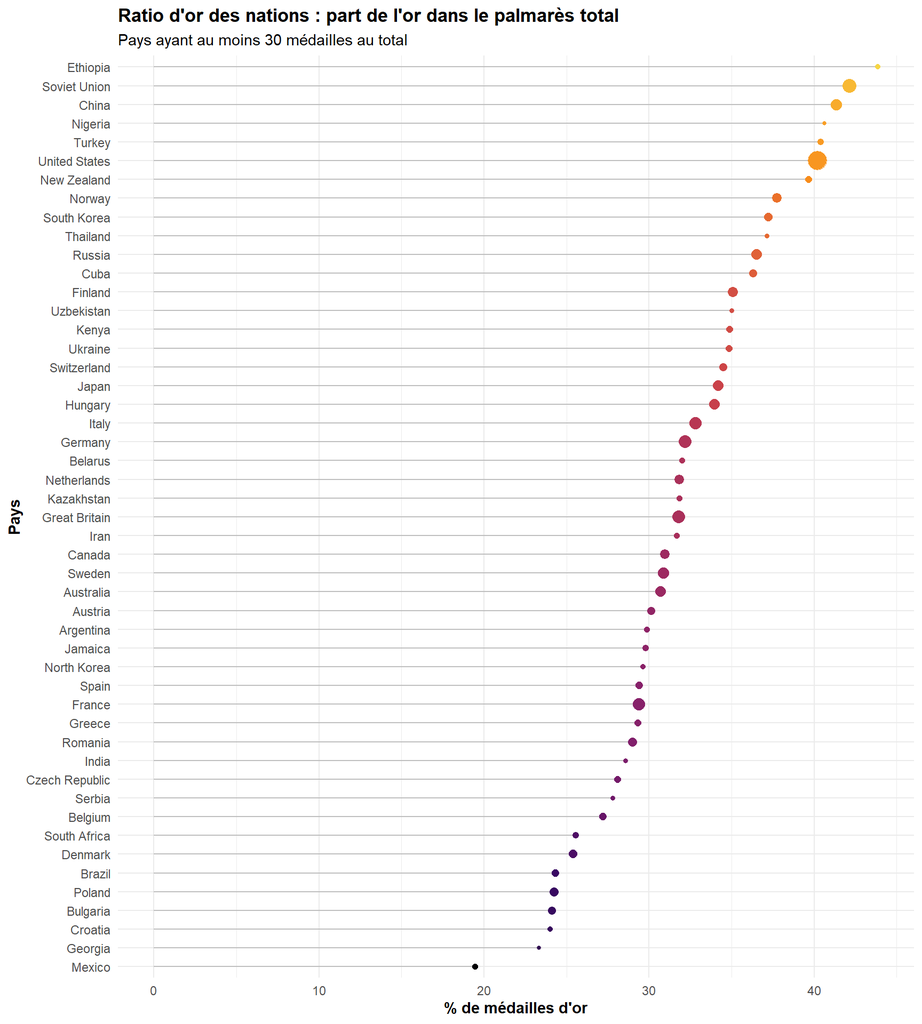

### Interprétation

Le graphique révèle **trois profils de nations** :

- **Les géants dominateurs** (gros points en haut) : l’Union soviétique (42 %), la **Chine** (41 %) et les **États-Unis** (40 %) cumulent à la fois un énorme volume de médailles et un ratio d’or élevé. Ce sont les vraies puissances : elles ne se contentent pas de participer aux podiums, elles les gagnent.
- **Les spécialistes** (petits points, ratio élevé) : l’**Éthiopie** (44 %), le **Nigeria** (41 %) ou la **Turquie** (40 %) affichent un ratio d’or aussi haut que les géants, mais sur un volume bien plus faible. Ce sont des nations qui dominent un **petit nombre de disciplines** (l’Éthiopie est historiquement reine du fond), ce qui est cohérent avec la réalité sportive.
- **Les collectionneuses** (bas du classement) : le **Mexique** (19 %), la **Pologne**, la **Bulgarie** ou le **Brésil** (≈ 24 %) accumulent les podiums mais transforment rarement en or.

On note tout de même que l’éventail des ratios reste resserré (≈ 19 % à 44 %), ce qui invite à la prudence : sur ce jeu de données, la part d’or tourne globalement autour de 30–40 %. La taille des points (le volume) reste donc le meilleur séparateur entre vraies puissances et nations de niche.

### Conclusion

En croisant le **volume** (taille des points) et la **qualité** (ratio d’or), ce dernier graphique synthétise élégamment la hiérarchie olympique : il distingue les nations qui gagnent gros, celles qui gagnent juste, et celles qui gagnent souvent sans gagner le titre.

# Question 23 : Application Shiny — un explorateur morphologique interactif

Pour permettre au lecteur d’explorer lui-même les empreintes morphologiques vues en Question 19, nous avons développé une **application Shiny** (dossier `/shiny/`). Plutôt que de figer un seul graphique, elle laisse l’utilisateur **choisir la discipline, la saison et le genre**, et observer en temps réel comment se déplace le nuage taille × poids et comment évolue la distribution de l’IMC.

*Les figures ci-dessous n’ont pas été générées directement dans ce rapport : ce sont des captures d’écran de l’application Shiny. Pour interagir avec ces graphiques, il faut lancer l’application (`/shiny/app.R`).*

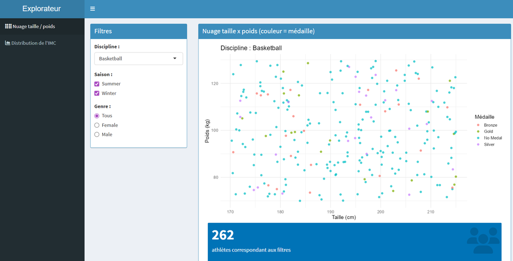

Onglet 1 de l’application Shiny : nuage taille x poids filtré par discipline, saison et genre, points colorés selon la médaille obtenue.

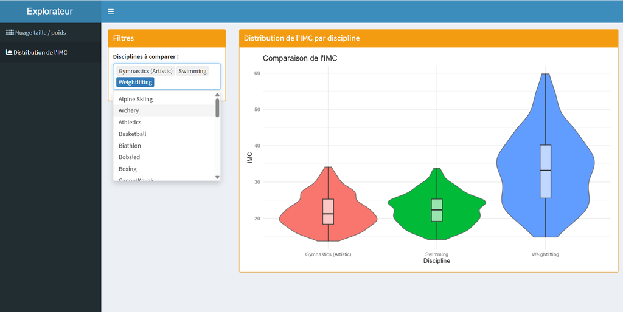

Onglet 2 de l’application Shiny : distribution de l’IMC pour les disciplines sélectionnées (violon interactif).

La première capture (nuage taille × poids) confirme de manière interactive ce que la Question 19 montrait : en sélectionnant successivement « Basketball » puis « Gymnastics (Artistic) », le nuage se déplace radicalement dans le plan, illustrant en direct la spécialisation des gabarits. Le filtre par saison et par genre permet en outre de vérifier que ces empreintes restent stables (les femmes suivent la même logique morphologique que les hommes, simplement décalée vers des gabarits un peu plus légers).

La seconde capture (violon d’IMC) permet de comparer interactivement deux ou trois disciplines au choix, et retrouve le classement de la Question 20 : l’haltérophilie domine toujours en IMC, la gymnastique reste tout en bas.

### Conclusion

L’application Shiny transforme une analyse figée en outil d’exploration : elle apporte une valeur ajoutée réelle par rapport à un graphique statique, puisqu’elle laisse le lecteur poser ses propres sous-questions.